# Exploratory Visualization of US Domestic Flights in Year 2009

Yunrou Gong (Crystal)

July 15, 2016

# Introduction

Airplane is one of the main transportation tools for carring people to travel around the world. Last year,over 798 million air passengers were transported include both domestic and international aircraft passengers of air carriers registered in the U.S.The number of passengers been carried was increased dramatically by around 72%, compared to that of year 1990. The air transport industry a vital engine of global socio-economic growth, is considerably important for economic development, creating direct and indirect employment, supporting tourism and local businesses, and stimulating foreign investment and international trade. Moreover, it is also played an crucial part in population movement and world exploration.Due to the huge historical records of the flights, we are able to do population flow analysis to get the insight of the moving behaviour of people.  
This report will use the historical records of US domestic flights during the year of 2009 to do the following analysises:visualization the air trafic in each airport to predit which is the larger hub or transit airport. Secondly, to check how the air traffic fluctuate through the year 2009. Additionaly, the article is going to define the pattern of population movemoent in US by air.

# Origin Data Set Description

## Abstract:

The origin data set is over 3.5 million monthly domestic flight records from 1990 to 2009. Data are arranged as an adjacency list with metadata.

### Fields:

Short name Type Description  
Origin String Three letter airport code of the origin airport  
Destination String Three letter airport code of the destination airport  
Origin City String Origin city name  
Destination City String Destination city name  
Passengers Integer Number of passengers transported from origin to destination  
Seats Integer Number of seats available on flights from origin to destination  
Flights Integer Number of flights between origin and destination (multiple records for one month, many with flights > 1)  
Distance Integer Distance (to nearest mile) flown between origin and destination  
Fly Date Integer The date (yyyymm) of flight  
Origin Population Integer Origin city’s population as reported by US Census  
Destination Population Integer Destination city’s population as reported by US Census

### Snippet:

MFR RDM Medford, OR Bend, OR 0 0 1 156 200810 200298 157730  
AMA EKO Amarillo, TX Elko, NV 124 124 1 858 199308 202960 40259  
TUS EKO Tucson, AZ Elko, NV 112 124 1 658 199308 711392 40259  
AMA EKO Amarillo, TX Elko, NV 115 124 1 858 199406 206315 41668  
ICT EKO Wichita, KS Elko, NV 100 124 1 1007 199607 552884 45034  
SPS EKO Wichita Falls, TX Elko, NV 122 124 1 1059 199603 147683 45034

### Source(s)

1.US Census Bureau  
2.RITA/Transtats, Bureau of Transportation Statistics

Year: 2009

URL: http://www.infochimps.com/datasets/35-million-us-domestic-flights-from-1990-to-2009

## Data Manipulation

Bascially, The original data set is abstracted into only one year of 2009 and remove the rows that the origin airport and destination airport is the same. Additionaly, I also delete the rows with zero value in column “Passengers”.

## Data set of Year 2009

```r
tbl_df(year2009)
```

```
## # A tibble: 178,268 x 13
##     Year Month Origin Destination     Origin.City Destination.City
##    <int> <int> <fctr>      <fctr>          <fctr>           <fctr>
## 1   2009     6    LAX         RDM Los Angeles, CA         Bend, OR
## 2   2009     3    LAX         RDM Los Angeles, CA         Bend, OR
## 3   2009    12    LAX         RDM Los Angeles, CA         Bend, OR
## 4   2009     1    LAX         RDM Los Angeles, CA         Bend, OR
## 5   2009    11    LAX         RDM Los Angeles, CA         Bend, OR
## 6   2009     5    LAX         RDM Los Angeles, CA         Bend, OR
## 7   2009     2    LAX         RDM Los Angeles, CA         Bend, OR
## 8   2009     7    LAX         RDM Los Angeles, CA         Bend, OR
## 9   2009     4    LAX         RDM Los Angeles, CA         Bend, OR
## 10  2009     2    LAX         RDM Los Angeles, CA         Bend, OR
## # ... with 178,258 more rows, and 7 more variables: Passengers <int>,
## #   Seats <int>, Flights <int>, Distance <int>, Fly.Date <int>,
## #   Origin.Population <int>, Destination.Population <int>
```

### Accumulative flow of passengers at each airport in year 2009

First, I calculate the accumulative outflow of passengers by using summarise function in dyplr and arrange the data by descending value. However, the observations are still too mcuh to analysis, which has 445 distinguish airports in rows.

```r
str(year2009_2)
```

```
## Classes 'tbl_df', 'tbl' and 'data.frame':    445 obs. of  3 variables:
##  $ Origin        : Factor w/ 445 levels "1B1","ABE","ABI",..: 31 316 112 233 231 332 90 202 263 293 ...
##  $ Passengers_out: int  34404073 24489548 22563679 19095716 16800451 16304031 14974084 14189884 13485397 13441406 ...
##  $ flights_out   : int  391849 329665 260597 184692 145011 161834 199212 197054 114203 171772 ...
```

Thus, I choose to filter the origin airport within the top 15 number of Passengers and plot it into bar chart.

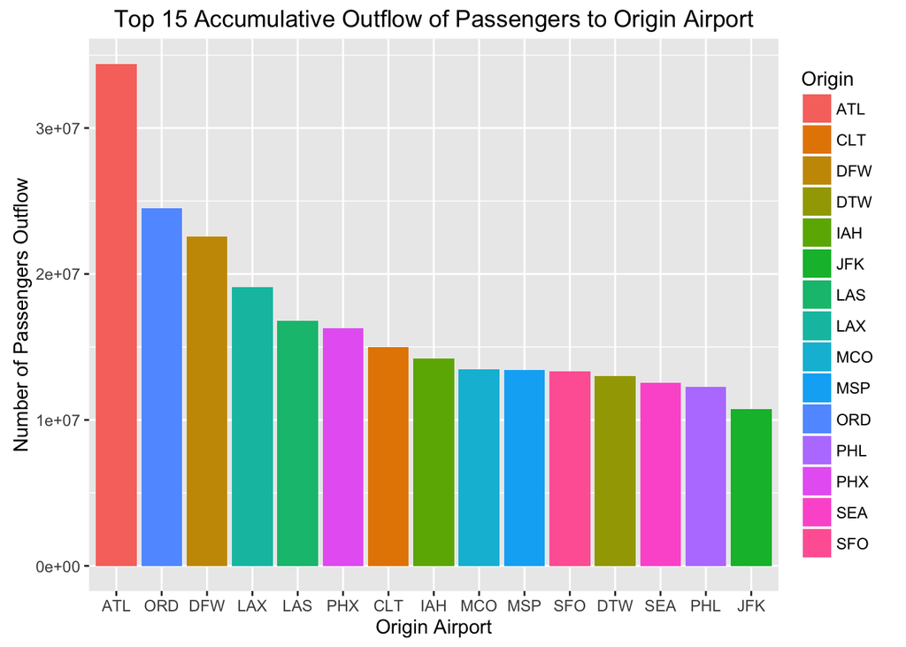

Meanwhile, filter the year 2009 data to get the destinaiton airport within top 15 inflow of passengers.

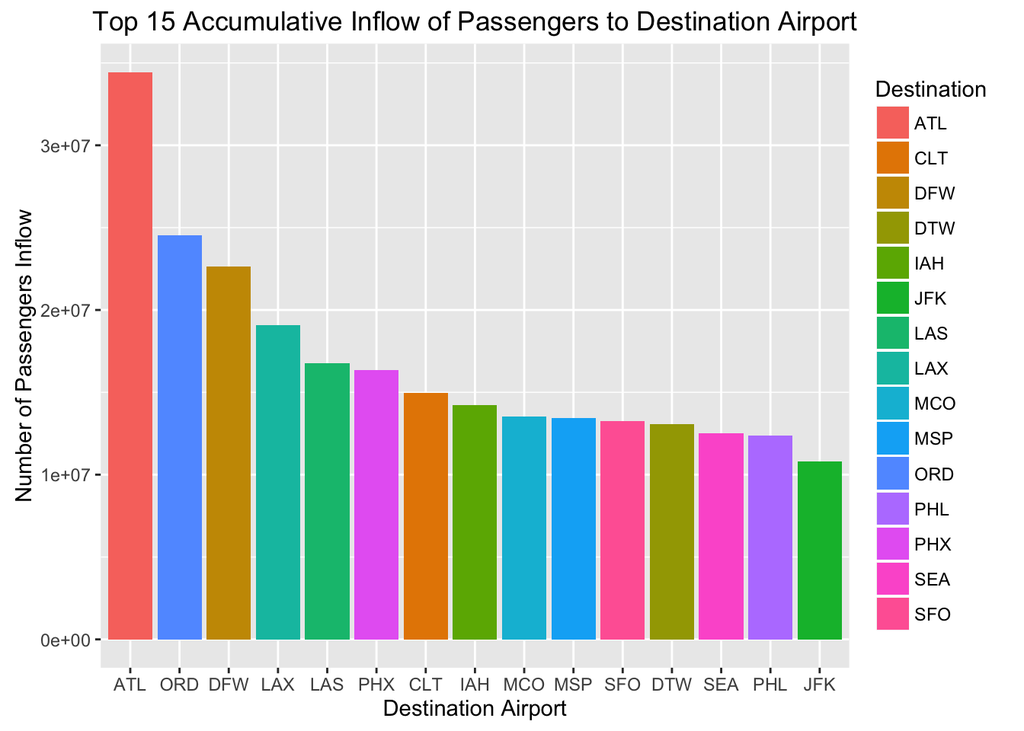

Compare the above two barcharts, it is easily to find out that the names of the origin airport are exact the same as the names of destination airport. In other words, the net passengers flow for each airport may approxiemately to zero. Take a further look into the Jackson Atlanta International Airport(ATL), it ranks at the first both of the total outflow and total inflow, which is make sense as the ATL is a large hub airport, also a transit airport.

## Analysis the population movement

Zoom into each month data and calculate the netflow of the passengers to explore how the passengers are moving around. For the simplicity and efficience, I select the airports with top 10 and last 10 netflow of passengers in each month.